# MI Wave 1 analyses: JNeuro reanalysis/replication

# 1 intro

```r
## libraries ----

library(here)
library(data.table)
source(here("src", "stroop-rsa-pc.R"))
library(knitr)
library(dplyr)
library(tidyr)
library(ggplot2)
library(mfutils)
library(ggseg)
library(ggsegExtra)
library(ggsegSchaefer)
library(ggsegGlasser)

## settings, params ----

opts_chunk$set(echo = TRUE, out.width = "100%")
theme_set(theme_bw(base_size = 10))

if (exists("params")) {
  ttype_subset <- params$ttype_subset
  prewh <- params$prewh
  measure <- params$measure
  roiset <- params$roiset
} else {
  ttype_subset <- "bias"
  prewh <- "obsall"
  measure <- "cveuc"
  roiset <- "glasser2016_parcel"
}

theme_surface <- list(
  theme(
    axis.text = element_blank(), panel.grid = element_blank(), panel.border = element_blank(),
    axis.ticks = element_blank(), legend.position = c(0.5, 0.5), legend.title = element_text(size = 5),
    legend.background = element_blank(), legend.text = element_text(size = 5), legend.direction = "horizontal",
    legend.key.height = unit(1/5, "cm"), legend.key.width = unit(1/4, "cm")
  )
)


## constants ----

wd <- here()
subjlists <- "mi1"
seswaves <- c("proactive_wave1")
glmname <- "lsall_1rpm"
sessions <- c("proactive")
statistics <- c("m", "t_stat")
titles <- c("mean coefficient", "t statistic")


## data ----

## read regression weights:

dat <- Map(
  function(subjlist, suffix) {
    fname <- construct_filename_weights(
        measure = measure, subjlist = subjlist, glmname = glmname,
        ttype_subset = ttype_subset, roiset = roiset, prewh = prewh, suffix = suffix
        )
    fread(fname)
  },
  subjlist = subjlists,
  suffix = paste0("__seswave-", seswaves)
)
dat <- rbindlist(dat)


## get ggseg atlas and format data to match:

dat <- dat %>% rename(region = roi)

if (roiset == "schaefer2018_17_200_parcel") {

  atlas <- schaefer17_200
  k <- schaefer2018_17_200_fsaverage5$key %>% select(region = parcel, network)

  rois <- data.frame(
    region = c(
    "17Networks_LH_ContA_PFClv_1",
    "17Networks_LH_ContA_PFCl_1",
    "17Networks_LH_ContA_PFCl_2",
    "17Networks_LH_ContA_PFCl_3",
    "17Networks_RH_ContA_PFCl_1",
    "17Networks_RH_ContA_PFCl_2",
    "17Networks_LH_SalVentAttnB_PFCmp_1",
    "17Networks_RH_SalVentAttnB_PFCmp_1",
    "17Networks_LH_SalVentAttnA_FrMed_1",
    "17Networks_RH_SalVentAttnA_FrMed_1"
    ),
    location = c(rep("lateral", 6), rep("medial", 4))
  )

} else if (roiset == "glasser2016_parcel") {

  atlas <- glasser
  k <- glasser2016_fsaverage5$key %>% select(region = parcel, network)

  dat <- dat %>% filter(!region %in% "L_10pp")  ## not in glasser ggseg atlas?
  ## create region column in ggseg atlas that matches data:
  hemi <- ifelse(atlas$data$hemi == "left", "L_", "R_")
  atlas$data$region <- ifelse(is.na(atlas$data$region), NA, paste0(hemi, atlas$data$region))

  rois <- data.frame(
    region = combo_paste(c("L_", "R_"), c("SCEF", "8BM",  "p32pr", "a32pr", "p9-46v", "i6-8", "8Av", "8C")),
    location = c(rep("medial", 8), rep("lateral", 8))
  )

}

## add network information:
atlas$data <- left_join(atlas$data, k, by = "region")
dat <- left_join(dat, k, by = "region")


## calculate ----

## add subject set information:
subjlists <- rbind(
  data.table(subjlist = "jneurosci", subject = fread(here("out", "subjlist_jneurosci_primary.txt"))[[1]]),
  data.table(subjlist = "replication", subject =
               fread(here("out", "subjlist_jneurosci_replication_primary.txt"))[[1]])
)
dat_subjs <- dat %>% inner_join(subjlists, by = "subject")
dat_subjs <- bind_rows(dat_subjs, dat_subjs %>% mutate(subjlist = "jneurosci \u222A replication"))

dat_sum <- dat_subjs %>%
  group_by(subjlist, session, term, wave, region) %>%
  summarize(
    m = mean(b),
    t_stat = t.test(b)$statistic,
    p = t.test(b, alternative = "greater")$p.value,
    .groups = "drop_last"
    ) %>%
  mutate(p_fdr = p.adjust(p, "fdr"))

dat_sum <- dat_sum %>% filter(term %in% models[[measure]])

n_subjs <- table(unique(dat_subjs[, c("subject", "subjlist")])$subjlist)
```

This file displays group-level RSA model coefficients (means, test statistics).

**Subject samples**:

Analyses are conducted with three different sets of subjects.

- the **jneurosci** set: N = 46, unrelated
  - The paper had N=49; 3 subjects are not included in these analyses: 873968, DMCC1971064, DMCC9478705
  - the latter subject is not included due to failed fmriprep preprocessing
  - the former two subjects were unintentionally excluded due to meeting jo’s criteria for “bad runs”: >20% of TRs excluded due to high motion (I am running these subjects now)
- the **replication** set: N = 21, unrelated (to each other and to those in jneurosci)
- the **jneurosci** $\bigcup$ **replication** set: N = 67, unrelated

# 2 Brains

## 2.1 Unthresholded

### 2.1.1 Common scale

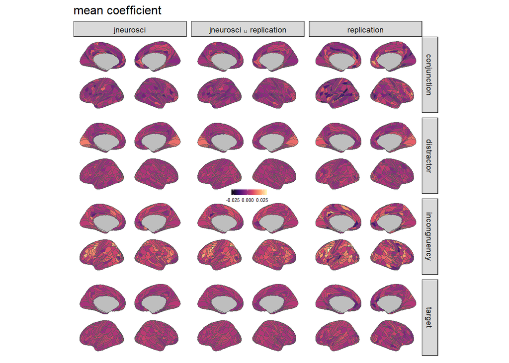

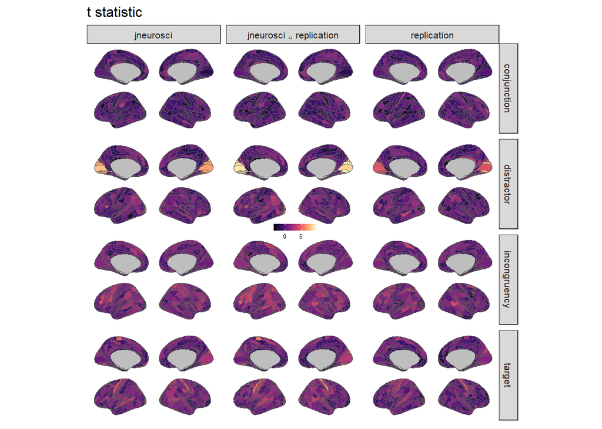

```r
for (stat_i in seq_along(statistics)) {

  p <- dat_sum %>%
    ggplot() +
    geom_brain(
      aes_string(fill = statistics[stat_i]),
      atlas = atlas, position = position_brain(side ~ hemi)
      ) +
    scale_fill_viridis_c(
      option = "magma", na.value = "grey",
      breaks = scales::extended_breaks(4)
      ) +
    facet_grid(rows = vars(term), cols = vars(subjlist)) +
    theme_surface +
    labs(title = titles[stat_i], fill = NULL)

  print(p)

}
```

### 2.1.2 Separate scales by model

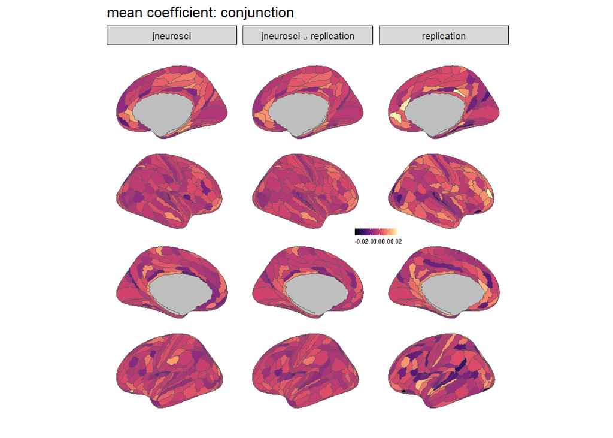

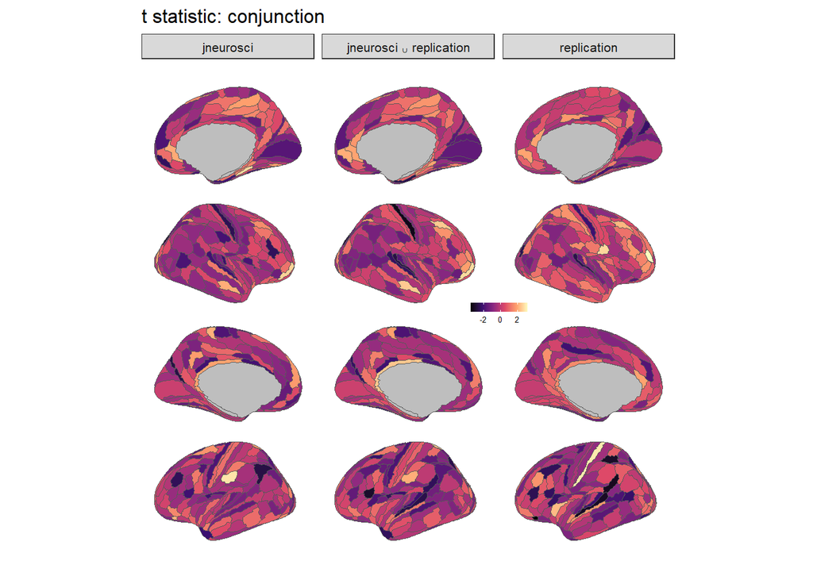

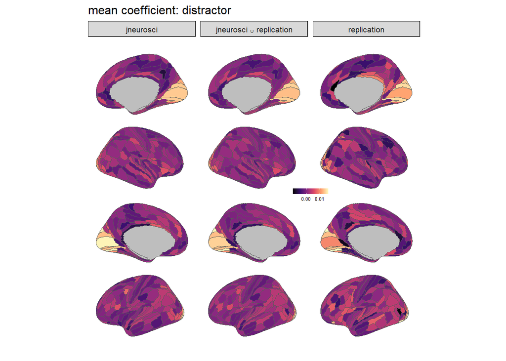

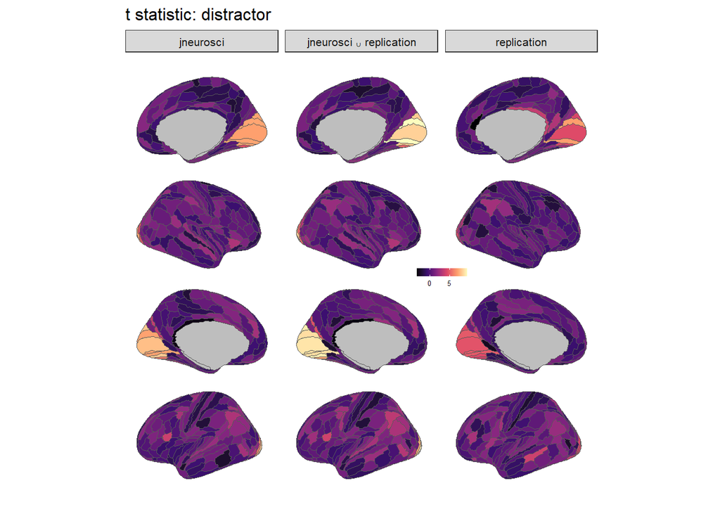

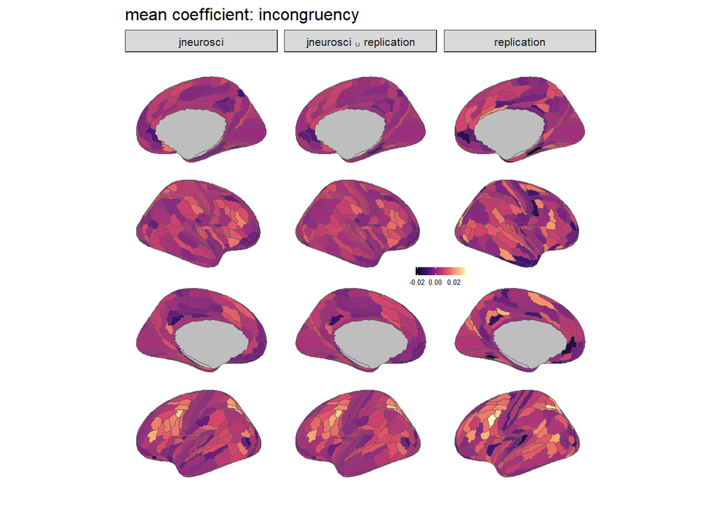

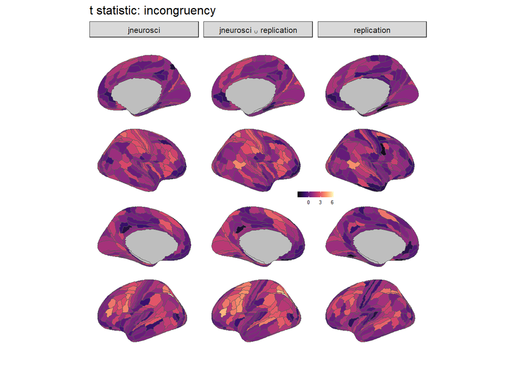

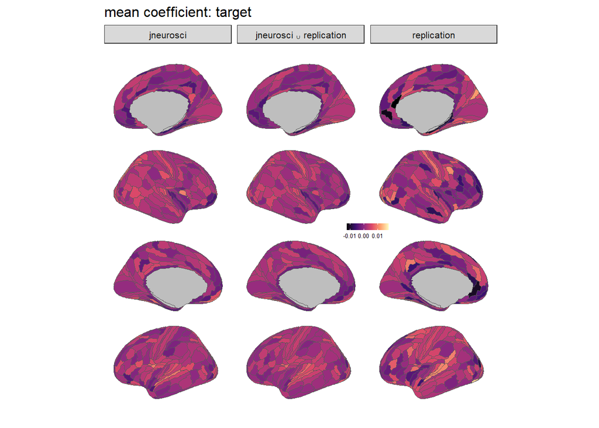

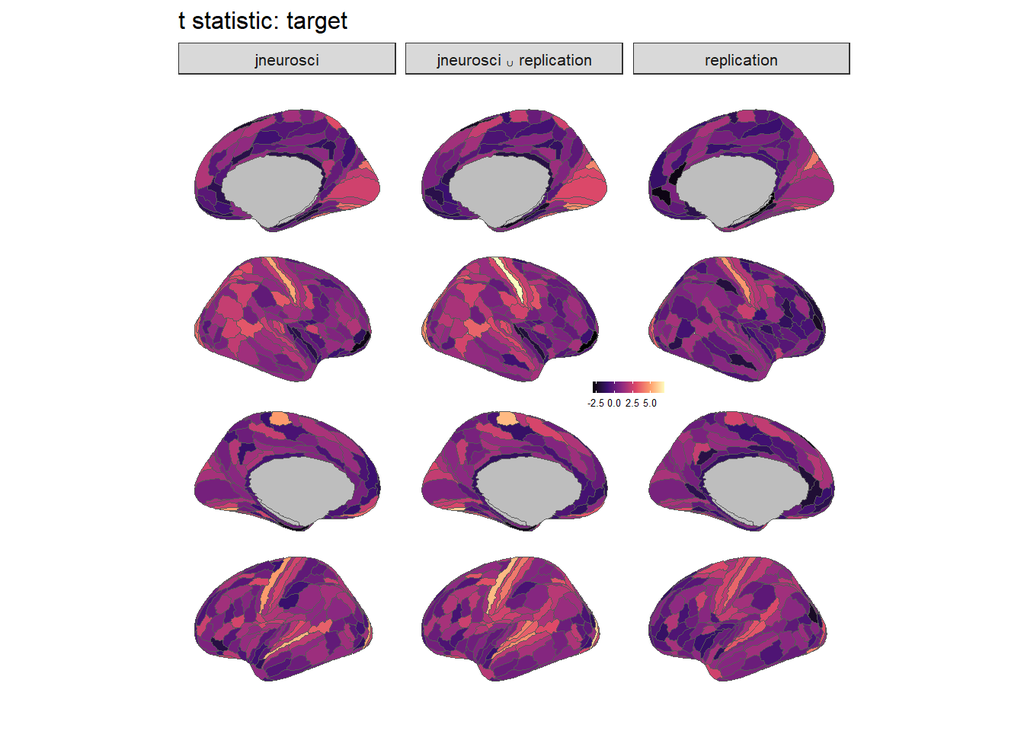

```r
for (model_i in seq_along(models[[measure]])) {

  model <- models[[measure]][model_i]

  for (stat_i in seq_along(statistics)) {

    p <- dat_sum %>%
      filter(term %in% model) %>%
      ggplot() +
      geom_brain(
        aes_string(fill = statistics[stat_i]),
        atlas = atlas, position = position_brain(hemi + side ~ .)
        ) +
      scale_fill_viridis_c(
        option = "magma", na.value = "grey",
        breaks = scales::extended_breaks(4)
        ) +
      facet_grid(cols = vars(subjlist)) +
      theme_surface +
      theme(legend.position = c(2/3, 0.5)) +
      labs(title = paste0(titles[stat_i], ": ", model), fill = NULL)

    print(p)

  }

}
```

## 2.2 Thresholded

Three consecutive thresholds are used, each more liberal than the previous:

- **p_FDR < 0.05**: parcels with mean model fit significantly greater than 0 following FDR correction over all parcels (separately per model)
- **p_uncorr < 0.05**: parcels with mean model fit significantly greater than 0 (uncorrected)
- **t_stat > 0**: parcels with mean model fit numerically greater than zero

### 2.2.1 Common scale

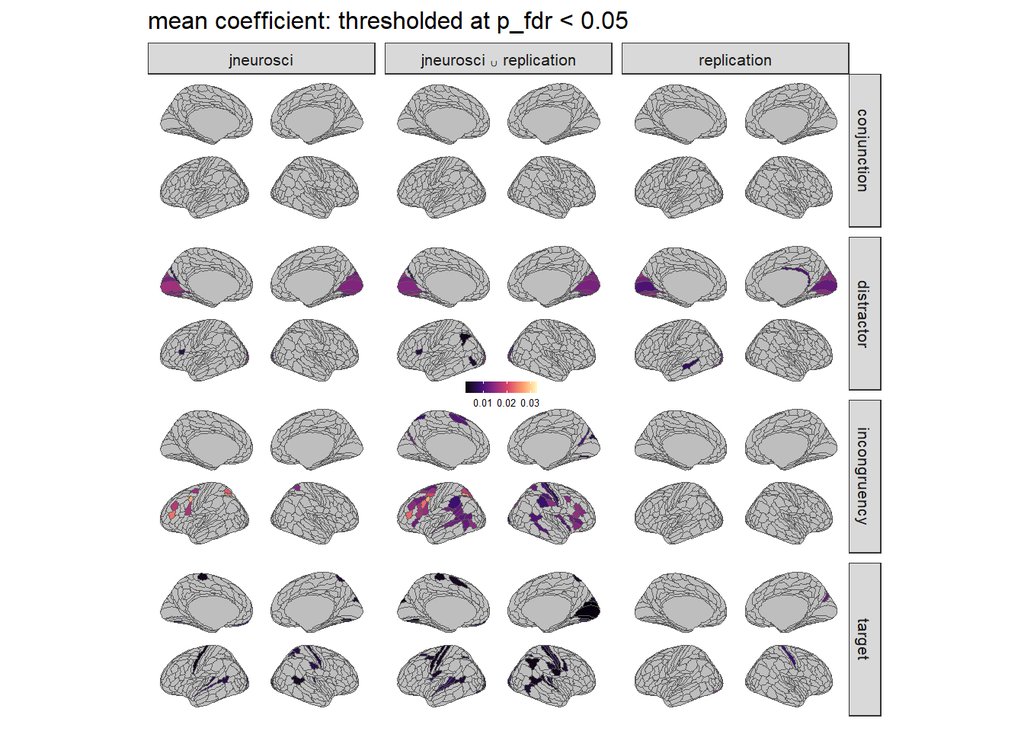

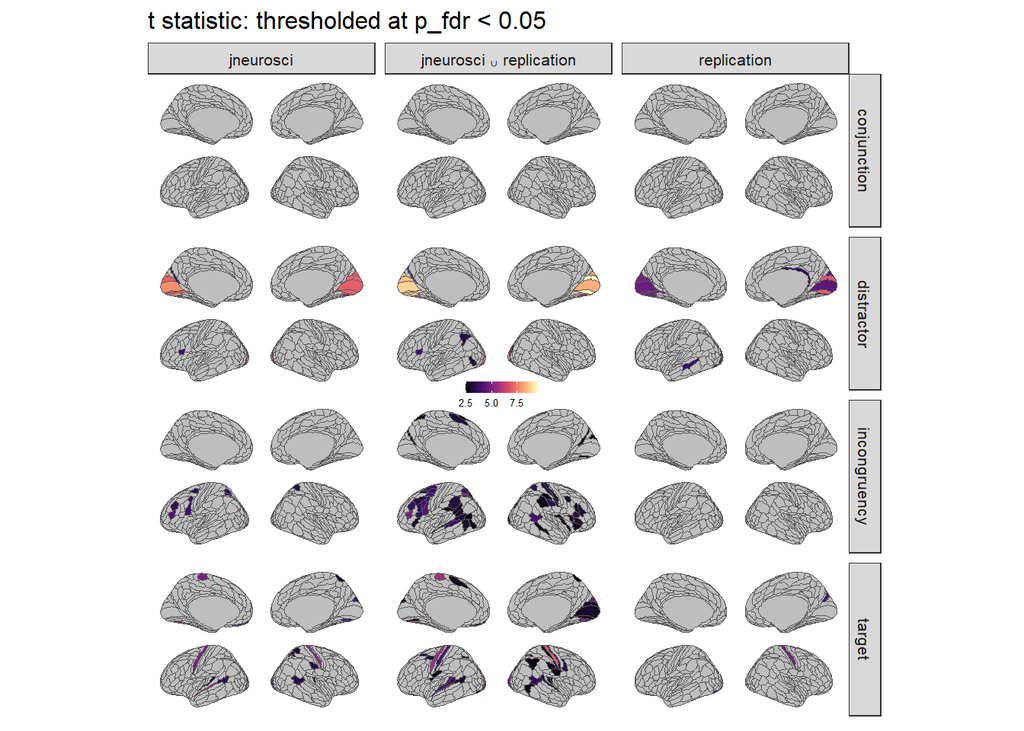

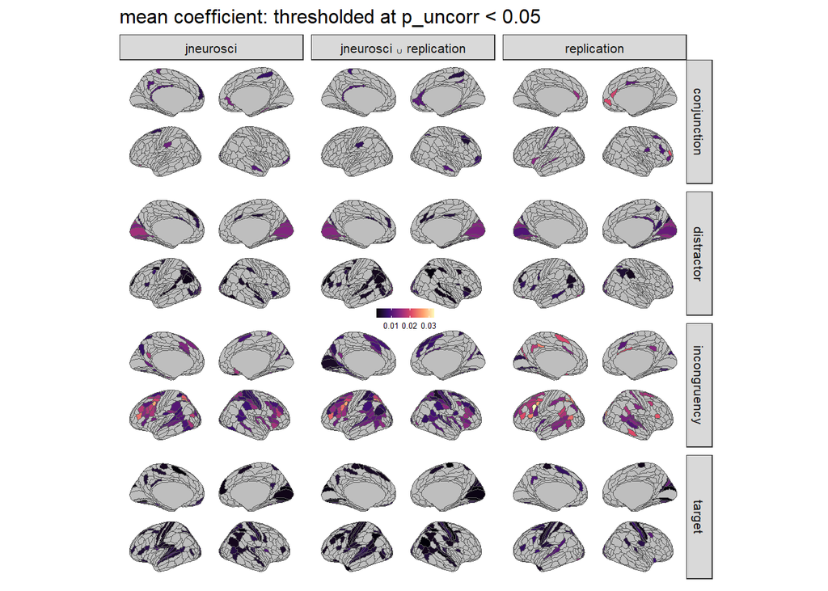

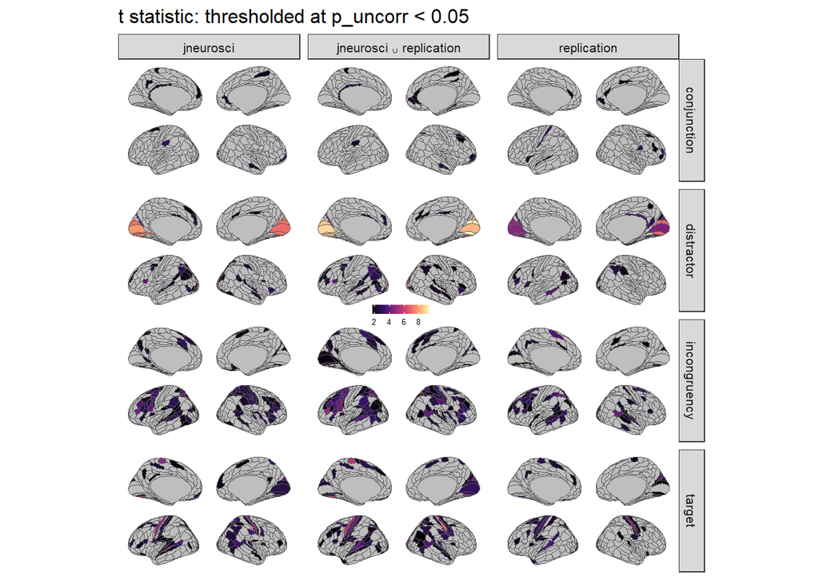

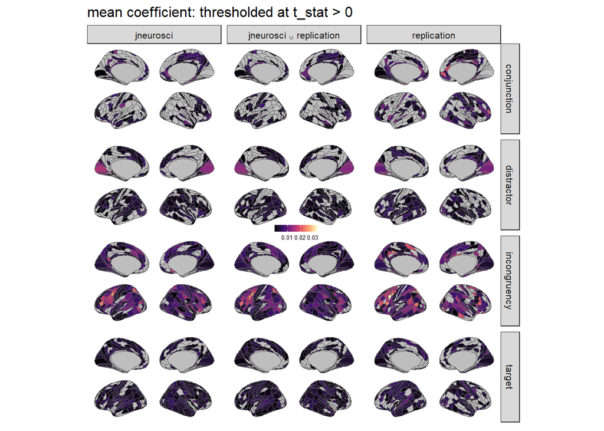

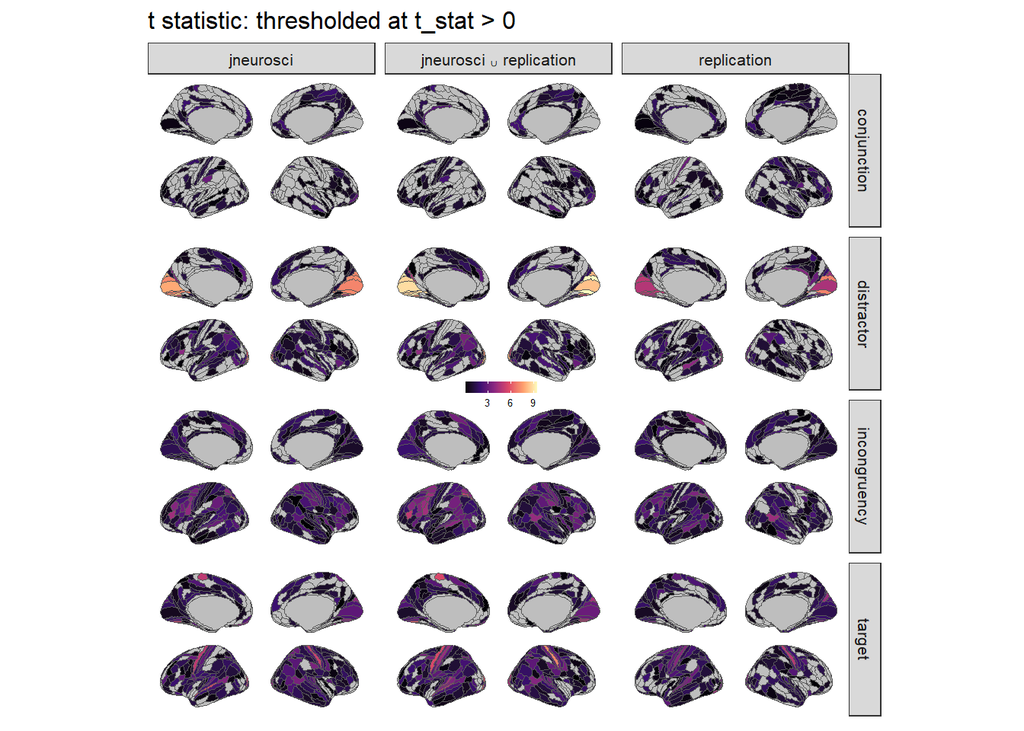

```r
dat_sum$is_in_thresh_fdr <- dat_sum$p_fdr < 0.05
dat_sum$is_in_thresh_p <- dat_sum$p < 0.05
dat_sum$is_in_thresh_sign <- dat_sum$t_stat > 0

thresholds <- c("p_fdr < 0.05", "p_uncorr < 0.05", "t_stat > 0")
thresholds_nms <- c("is_in_thresh_fdr", "is_in_thresh_p", "is_in_thresh_sign")

for (thresh_i in seq_along(thresholds)) {

  threshold_nm <- thresholds_nms[thresh_i]

  for (stat_i in seq_along(statistics)) {

    dat_sum$thresh <- as.numeric(ifelse(dat_sum[[threshold_nm]], dat_sum[[statistics[stat_i]]], NA))

    p <- dat_sum %>%
      ggplot() +
      geom_brain(
        aes(fill = thresh),
        atlas = atlas, position = position_brain(side ~ hemi)
        ) +
      scale_fill_viridis_c(
        option = "magma", na.value = "grey",
        breaks = scales::extended_breaks(4)
        ) +
      facet_grid(rows = vars(term), cols = vars(subjlist)) +
      theme_surface +
      labs(title = paste0(titles[stat_i], ": thresholded at ", thresholds[thresh_i]), fill = NULL)

    print(p)

  }

}
```

# 3 Tables

## 3.1 Do identified parcels replicate?

Parcels within the **jneurosci** sample that survived FDR correction (whole-cortex) are identified. Are these parcels still significant (uncorrected) in the **replication** sample?

Displayed are stats within the replication sample for “successfully replicated” parcels (p<0.05).

```r
sig_orig <- dat_sum %>% filter(p_fdr < 0.05, subjlist == "jneurosci") %>% ungroup %>% select(term, region)

d <- enlist(c("target", "distractor", "incongruency"))
for (model in names(d)) {

  d[[model]] <- dat_sum %>%
    ungroup %>%
    filter(
      subjlist == "replication", term == model, region %in% sig_orig$region[sig_orig$term == model], p < 0.05
    ) %>%
    select(region, m, t_stat, p) %>%
    arrange(region)

}

lapply(d, kable)
```

$target

| region | m | t_stat | p |
| --- | --- | --- | --- |
| L_4 | 0.0033489 | 2.694025 | 0.0069796 |
| L_PBelt | 0.0099965 | 3.235756 | 0.0020718 |
| L_V4 | 0.0061094 | 3.058399 | 0.0031012 |
| R_3b | 0.0082962 | 4.764072 | 0.0000592 |
| R_V3 | 0.0052130 | 2.219589 | 0.0190857 |
| R_V4 | 0.0094800 | 3.533325 | 0.0010438 |
| R_V8 | 0.0179049 | 5.356786 | 0.0000152 |

$distractor

| region | m | t_stat | p |
| --- | --- | --- | --- |
| L_DVT | 0.0068812 | 2.920869 | 0.0042253 |
| L_V1 | 0.0095678 | 4.645325 | 0.0000780 |
| L_V2 | 0.0129455 | 4.826791 | 0.0000512 |
| L_V3 | 0.0163624 | 4.373030 | 0.0001471 |
| L_V4 | 0.0098922 | 4.017280 | 0.0003378 |
| R_V1 | 0.0114040 | 4.414119 | 0.0001336 |
| R_V2 | 0.0145188 | 6.880506 | 0.0000006 |
| R_V3 | 0.0135061 | 4.156915 | 0.0002437 |
| R_V4 | 0.0076418 | 2.473623 | 0.0112307 |

$incongruency

| region | m | t_stat | p |
| --- | --- | --- | --- |
| L_6r | 0.0114789 | 1.766633 | 0.0462744 |
| L_IFSa | 0.0203157 | 2.515213 | 0.0102771 |
| L_IP0 | 0.0207574 | 2.240091 | 0.0183008 |
| L_IP1 | 0.0152570 | 2.006411 | 0.0292624 |
| L_LIPd | 0.0313538 | 3.842771 | 0.0005079 |
| L_PEF | 0.0271205 | 1.941882 | 0.0331851 |

## 3.2 FDR significant parcels in the full dataset

Displayed are parcels that are significant after FDR correction (whole-cortex) in the higher-powered jneurosci+replication sample.

```r
sig_all <- dat_sum %>%
  filter(p_fdr < 0.05, !subjlist %in% c("jneurosci", "replication")) %>%
  ungroup %>%
  select(term, region)

d <- enlist(c("target", "distractor", "incongruency"))
for (model in names(d)) {

  d[[model]] <- dat_sum %>%
    ungroup %>%
    filter(
      !subjlist %in% c("jneurosci", "replication"),
      term == model,
      region %in% sig_all$region[sig_all$term == model],
      p_fdr < 0.05
    ) %>%
    select(region, m, t_stat, p) %>%
    arrange(region)

}

lapply(d, kable)
```

$target

| region | m | t_stat | p |
| --- | --- | --- | --- |
| L_10v | 0.0059053 | 3.216055 | 0.0010070 |
| L_13l | 0.0051022 | 2.998445 | 0.0019117 |
| L_3b | 0.0040269 | 4.045741 | 0.0000696 |
| L_4 | 0.0034152 | 5.545848 | 0.0000003 |
| L_55b | 0.0045733 | 3.123914 | 0.0013254 |
| L_A4 | 0.0058392 | 3.466343 | 0.0004664 |
| L_A5 | 0.0066856 | 4.585391 | 0.0000104 |
| L_FOP2 | 0.0078800 | 2.784711 | 0.0034921 |
| L_i6-8 | 0.0058724 | 3.249392 | 0.0009106 |
| L_LIPd | 0.0053956 | 3.202882 | 0.0010476 |
| L_OP4 | 0.0043311 | 2.658102 | 0.0049243 |
| L_PBelt | 0.0075453 | 4.305104 | 0.0000283 |
| L_PIT | 0.0064350 | 2.675683 | 0.0046976 |
| L_SCEF | 0.0037791 | 2.797071 | 0.0033750 |
| L_TPOJ1 | 0.0047398 | 3.006410 | 0.0018682 |
| L_V3 | 0.0023314 | 2.864192 | 0.0028001 |
| L_V4 | 0.0059441 | 5.902928 | 0.0000001 |
| L_V8 | 0.0067057 | 2.699849 | 0.0044016 |
| L_VVC | 0.0067791 | 3.548867 | 0.0003592 |
| R_1 | 0.0034063 | 2.822728 | 0.0031435 |
| R_3a | 0.0030087 | 3.330705 | 0.0007107 |
| R_3b | 0.0065142 | 6.963487 | 0.0000000 |
| R_6v | 0.0045628 | 3.232346 | 0.0009588 |
| R_7Am | 0.0041515 | 2.609325 | 0.0056063 |
| R_A1 | 0.0053543 | 2.584363 | 0.0059875 |
| R_A4 | 0.0042128 | 2.923257 | 0.0023704 |
| R_IP0 | 0.0056930 | 2.700489 | 0.0043940 |
| R_IPS1 | 0.0076544 | 3.051015 | 0.0016415 |
| R_LBelt | 0.0054711 | 3.085937 | 0.0014822 |
| R_LIPd | 0.0059292 | 3.454252 | 0.0004844 |
| R_OP4 | 0.0033972 | 2.652542 | 0.0049980 |
| R_PFm | 0.0030948 | 2.632615 | 0.0052706 |
| R_PFop | 0.0045979 | 2.827094 | 0.0031056 |
| R_PHT | 0.0050221 | 2.738772 | 0.0039604 |
| R_TPOJ1 | 0.0036626 | 3.577380 | 0.0003280 |
| R_V1 | 0.0026503 | 2.939231 | 0.0022652 |
| R_V2 | 0.0023147 | 2.862597 | 0.0028127 |
| R_V3 | 0.0048104 | 4.372978 | 0.0000222 |
| R_V3B | 0.0089633 | 3.593371 | 0.0003116 |
| R_V4 | 0.0069226 | 4.794222 | 0.0000048 |
| R_V7 | 0.0064010 | 2.712806 | 0.0042500 |
| R_V8 | 0.0122725 | 5.227576 | 0.0000009 |
| R_VVC | 0.0080924 | 3.624749 | 0.0002817 |

$distractor

| region | m | t_stat | p |
| --- | --- | --- | --- |
| L_44 | 0.0055384 | 3.882064 | 0.0001210 |
| L_DVT | 0.0067054 | 4.510748 | 0.0000136 |
| L_FST | 0.0046309 | 3.043975 | 0.0016755 |
| L_PFm | 0.0033376 | 3.286329 | 0.0008140 |
| L_V1 | 0.0138937 | 8.797586 | 0.0000000 |
| L_V2 | 0.0128758 | 8.567453 | 0.0000000 |
| L_V3 | 0.0158578 | 8.988402 | 0.0000000 |
| L_V4 | 0.0098228 | 7.124044 | 0.0000000 |
| L_V8 | 0.0101271 | 4.172505 | 0.0000450 |
| R_V1 | 0.0128286 | 8.258590 | 0.0000000 |
| R_V2 | 0.0138569 | 9.448304 | 0.0000000 |
| R_V3 | 0.0122864 | 8.058331 | 0.0000000 |
| R_V3CD | 0.0073340 | 3.025037 | 0.0017702 |
| R_V4 | 0.0077153 | 5.108783 | 0.0000015 |

$incongruency

| region | m | t_stat | p |
| --- | --- | --- | --- |
| L_44 | 0.0164058 | 3.671938 | 0.0002418 |
| L_55b | 0.0193752 | 4.122912 | 0.0000534 |
| L_6a | 0.0108097 | 3.690017 | 0.0002280 |
| L_6ma | 0.0102912 | 2.733691 | 0.0040156 |
| L_6r | 0.0150344 | 4.209554 | 0.0000395 |
| L_7Am | 0.0080645 | 2.640397 | 0.0051626 |
| L_8C | 0.0122872 | 3.267059 | 0.0008632 |
| L_A5 | 0.0120086 | 3.057731 | 0.0016097 |
| L_DVT | 0.0118780 | 2.614310 | 0.0055328 |
| L_FEF | 0.0154167 | 3.618579 | 0.0002874 |
| L_FOP5 | 0.0117628 | 2.812885 | 0.0032306 |
| L_FST | 0.0146223 | 2.706917 | 0.0043183 |
| L_i6-8 | 0.0155339 | 2.910643 | 0.0024567 |
| L_IFJa | 0.0164946 | 3.566887 | 0.0003392 |
| L_IFJp | 0.0227706 | 4.028622 | 0.0000738 |
| L_IFSa | 0.0223594 | 4.912927 | 0.0000031 |
| L_IP0 | 0.0228616 | 4.512658 | 0.0000135 |
| L_IP1 | 0.0271740 | 6.233524 | 0.0000000 |
| L_IP2 | 0.0129552 | 3.386849 | 0.0005977 |
| L_LIPd | 0.0269966 | 5.153278 | 0.0000013 |
| L_LIPv | 0.0183685 | 3.855269 | 0.0001323 |
| L_MIP | 0.0168160 | 3.633615 | 0.0002738 |
| L_p9-46v | 0.0145277 | 3.612425 | 0.0002931 |
| L_PEF | 0.0271864 | 4.077162 | 0.0000625 |
| L_PF | 0.0084768 | 3.194524 | 0.0010742 |
| L_PFcm | 0.0126594 | 2.624066 | 0.0053916 |
| L_PHT | 0.0112337 | 3.023907 | 0.0017760 |
| L_PSL | 0.0110609 | 2.871328 | 0.0027446 |
| L_SCEF | 0.0101334 | 3.151106 | 0.0012228 |
| L_SFL | 0.0096632 | 2.476122 | 0.0079271 |
| L_STSdp | 0.0122368 | 3.759118 | 0.0001819 |
| L_STV | 0.0123387 | 3.064967 | 0.0015760 |
| L_TPOJ1 | 0.0106880 | 2.950728 | 0.0021921 |
| L_TPOJ2 | 0.0109864 | 2.532351 | 0.0068584 |
| L_VIP | 0.0141919 | 2.806823 | 0.0032853 |
| R_1 | 0.0092562 | 3.060517 | 0.0015966 |
| R_3b | 0.0066189 | 3.001517 | 0.0018948 |
| R_44 | 0.0152309 | 3.260341 | 0.0008809 |
| R_6ma | 0.0108180 | 3.361125 | 0.0006472 |
| R_7PC | 0.0114022 | 3.370646 | 0.0006284 |
| R_AVI | 0.0140819 | 2.740011 | 0.0039471 |
| R_DVT | 0.0095032 | 2.779164 | 0.0035458 |
| R_FFC | 0.0103549 | 2.710399 | 0.0042778 |
| R_FOP4 | 0.0124004 | 2.868858 | 0.0027637 |
| R_FOP5 | 0.0114775 | 2.922958 | 0.0023724 |
| R_IFJa | 0.0148494 | 2.692684 | 0.0044875 |
| R_IFSp | 0.0141227 | 3.060307 | 0.0015976 |
| R_Ig | 0.0119711 | 2.463767 | 0.0081811 |
| R_IP0 | 0.0141999 | 2.948116 | 0.0022085 |
| R_IPS1 | 0.0135375 | 2.708341 | 0.0043017 |
| R_PEF | 0.0138425 | 2.923644 | 0.0023678 |
| R_PF | 0.0081451 | 2.683286 | 0.0046026 |
| R_PFop | 0.0145911 | 3.524614 | 0.0003880 |
| R_PFt | 0.0100889 | 2.693394 | 0.0044790 |
| R_PoI2 | 0.0096900 | 2.661643 | 0.0048779 |
| R_STSvp | 0.0101061 | 2.590712 | 0.0058884 |
| R_TPOJ1 | 0.0096685 | 3.962316 | 0.0000924 |
| R_V3 | 0.0062329 | 2.604546 | 0.0056775 |
| R_V7 | 0.0162028 | 2.476263 | 0.0079242 |

## 3.3 ROI-based analysis

Which ROIs (parcels) survive FDR correction over the reduced set of 16 ROIs? This is tested separately for each subject set (jneuro, replication, jneuro+replication).

```r
dat_sum_rois <- dat_sum %>% filter(region %in% rois$region) %>% mutate(p_fdr = p.adjust(p, "fdr"))

d <- enlist(c("target", "distractor", "incongruency"))
for (model in names(d)) {

  d[[model]] <- dat_sum_rois %>%
    ungroup %>%
    filter(term == model, p_fdr < 0.05) %>%
    select(region, subjlist, m, t_stat, p, p_fdr) %>%
    arrange(region, subjlist)
}

lapply(d, kable)
```

$target

| region | subjlist | m | t_stat | p | p_fdr |
| --- | --- | --- | --- | --- | --- |
| L_i6-8 | jneurosci ∪ replication | 0.0058724 | 3.249392 | 0.0009106 | 0.0145703 |
| L_SCEF | jneurosci ∪ replication | 0.0037791 | 2.797071 | 0.0033750 | 0.0270003 |

$distractor

| region | subjlist | m | t_stat | p | p_fdr |
| --- | --- | --- | --- | --- | --- |

$incongruency

| region | subjlist | m | t_stat | p | p_fdr |
| --- | --- | --- | --- | --- | --- |
| L_8Av | jneurosci ∪ replication | 0.0090250 | 2.291232 | 0.0125750 | 0.0258607 |
| L_8BM | jneurosci | 0.0129879 | 2.485206 | 0.0083657 | 0.0408055 |
| L_8BM | jneurosci ∪ replication | 0.0087611 | 2.014038 | 0.0240424 | 0.0384678 |
| L_8C | jneurosci | 0.0101407 | 2.127055 | 0.0194658 | 0.0444932 |
| L_8C | jneurosci ∪ replication | 0.0122872 | 3.267059 | 0.0008632 | 0.0065214 |
| L_8C | replication | 0.0169890 | 2.859786 | 0.0048420 | 0.0387361 |
| L_i6-8 | jneurosci | 0.0161591 | 2.310456 | 0.0127517 | 0.0408055 |
| L_i6-8 | jneurosci ∪ replication | 0.0155339 | 2.910643 | 0.0024567 | 0.0098268 |
| L_p32pr | jneurosci | 0.0133888 | 2.942128 | 0.0025682 | 0.0205453 |
| L_p32pr | jneurosci ∪ replication | 0.0091034 | 2.365326 | 0.0104808 | 0.0258607 |
| L_p9-46v | jneurosci | 0.0174939 | 3.566626 | 0.0004359 | 0.0069743 |
| L_p9-46v | jneurosci ∪ replication | 0.0145277 | 3.612425 | 0.0002931 | 0.0046897 |
| L_SCEF | jneurosci ∪ replication | 0.0101334 | 3.151106 | 0.0012228 | 0.0065214 |
| L_SCEF | replication | 0.0199836 | 3.527786 | 0.0010573 | 0.0169164 |
| R_8C | jneurosci | 0.0087924 | 2.153990 | 0.0183168 | 0.0444932 |
| R_8C | jneurosci ∪ replication | 0.0076863 | 2.261992 | 0.0134985 | 0.0258607 |
| R_p32pr | jneurosci ∪ replication | 0.0079034 | 2.240564 | 0.0142127 | 0.0258607 |
| R_p9-46v | jneurosci | 0.0111847 | 2.322984 | 0.0123794 | 0.0408055 |
| R_SCEF | jneurosci ∪ replication | 0.0087672 | 2.230870 | 0.0145467 | 0.0258607 |

# 4 Bar plots

```r
## prep for plotting:

dat_subjs_barplots <- dat_subjs %>%
  mutate(
    term = factor(term, levels = c("target", "incongruency", "distractor")),
    region_nice = gsub("17Networks_", "", region)
    ) %>%
  filter(term %in% c("target", "distractor", "incongruency"))
```

## 4.1 ROIs

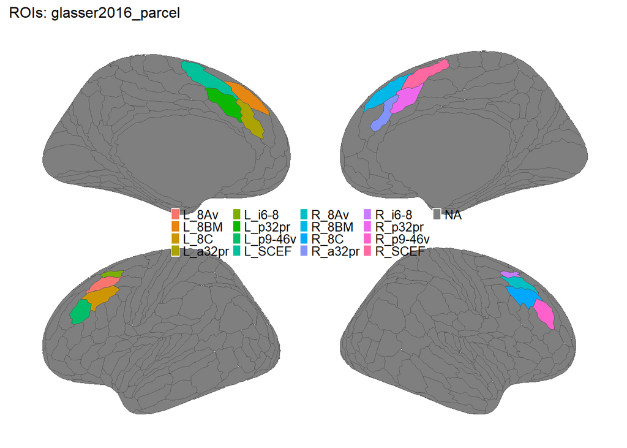

```r
atlas$data %>%
  ggplot() +
    geom_brain(
      aes(fill = ifelse(region %in% rois$region, region, NA)),
      atlas = atlas, position = position_brain(side ~ hemi)
      ) +
  labs(title = paste0("ROIs: ", roiset), fill = NULL) +
  theme_surface +
  theme(legend.text = element_text(size = 10))
```

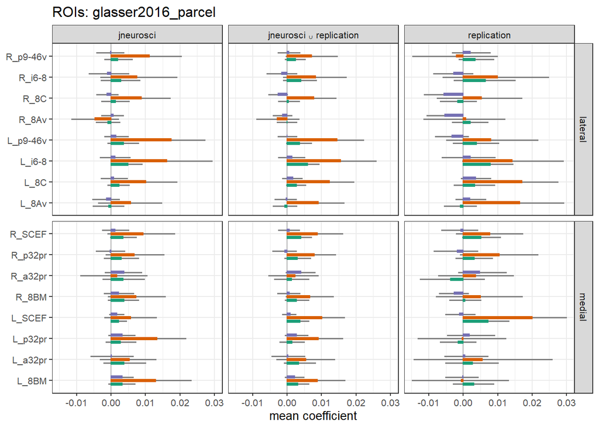

```r
dat_subjs_barplots %>%

  right_join(rois, by = "region") %>%

  ggplot(aes(region_nice, b, fill = term, color = term)) +
  geom_hline(yintercept = 0, color = "grey70") +
  stat_summary(
    fun.data = mean_cl_boot, geom = "errorbar", width = 0, size = 2/3, position = position_dodge(width = 0.5),
    color = "grey50"
    ) +
  stat_summary(fun = mean, geom = "col", width = 1/3, position = position_dodge(width = 0.5)) +

  scale_color_brewer(type = "qual", palette = 2) +
  scale_fill_brewer(type = "qual", palette = 2) +

  facet_grid(cols = vars(subjlist), rows = vars(location), scales = "free_y") +
  theme(
    #axis.text.x = element_text(angle = 90, hjust = 1, vjust = 0.5),
    legend.position = "none", axis.title.y = element_blank()
    ) +
    labs(y = "mean coefficient", title = paste0("ROIs: ", roiset)) +
  coord_flip()
```